# computational_flow_cytometry

Gabriel Rosenfeld

## Background

This tutorial will cover the basics of computational flow cytometry analysis. The goal is to introduce the fundamental aspects of such an analysis including reading/writing .fcs files, common data analysis steps, and visualizations. It is appropriate for those with a basic understanding of R and experience with flow cytometry data.

The course contains an R script from which the entire step by step analysis can be performed `computational_flow_cytometry.R` as well as this R markdown file in which the specific steps of the analysis can be observed while following along. This course expects R4.3.1+ is installed along with the complete set of R packages in the `installation.R` script.

## Set up

If the required R packages are not already installed on your machine, then uncomment and execute the R code below:

```r
# source("installation.R")
```

## Tutorial

Load the required libraries,

```r
library(flowCore)
library(ggcyto)
library(flowAI)
library(openCyto)
library(tidyverse)
library(magrittr)
```

Load Bcells tutorial dataset and save as object `fs` short for flowset,

```r
data("Bcells")
fs <- Bcells
```

The flowset object consists of individual flow frames. The `fs` object we are working with has 3 such flow frames in it.

```r
fs
```

```
## A flowSet with 3 experiments.
##
## column names(13): FSC-A FSC-H ... PE-Cy7-A Time
```

Indexing into the flowset is similar to working with lists or vectors in R. Here we identify the first flow frame in this flowset and save it as an R object

```r
ff <- fs[[1]]
```

Lets briefly explore the data. Each flow frame has the same columns (corresponding to a channel on the flow cytometer that collected the data). Each channels has a range of values.

```r
flowCore::summary(fs)
```

```
## $Bcells1
##               FSC-A    FSC-H       SSC-A     SSC-H  APC-Cy7-A Pacific Blue-A
## Min.    -6206062.00  20017.0 -7373237.50      0.00 -25890.150    -22560.8711
## 1st Qu.    67875.02  62832.0    49038.22  44964.00    260.100       116.2500
## Median    125960.58 110023.0    63117.12  56656.00    986.000       291.0900
## Mean       70895.99 104979.0    46799.08  74858.33   3362.706       364.6518
## 3rd Qu.   160405.92 129793.8   125881.36 104907.25   4010.300       417.5700
## Max.      262143.00 259407.0   262143.00 257790.00 262143.000    262143.0000
##            AmCyan-A Qdot 605-A Qdot 655-A       PE-A PE-Texas Red-A   PE-Cy7-A
## Min.     -7294.9199  -5563.260 -29802.779  -6746.140      -4192.660  -3871.220
## 1st Qu.    136.7100    293.880     53.940     71.340         49.200    204.180
## Median     305.9700    956.040    410.595    274.700        199.260   1513.720
## Mean       709.2158   4591.473  17721.475   3955.227       1296.673   4127.204
## 3rd Qu.    931.8600   2515.650   1129.020   1133.240        667.480   6055.495
## Max.    190194.2969 262143.000 262143.000 262143.000     262143.000 262143.000
##              Time
## Min.       0.0000
## 1st Qu.  782.8999
## Median  1689.8003
## Mean    1666.7029
## 3rd Qu. 2401.5752
## Max.    4723.6001
##
## $Bcells2
##              FSC-A     FSC-H       SSC-A     SSC-H  APC-Cy7-A Pacific Blue-A
## Min.    -6068660.0  20017.00 -7298877.50      0.00 -23233.900    -23348.5801
## 1st Qu.   110556.6  95822.25    51387.38  47040.50    233.750       211.1100
## Median    128862.9 112000.50    62727.28  56594.00    839.375       313.4100
## Mean      122202.5 105678.62    75375.22  67853.09   3303.097       621.1054
## 3rd Qu.   156726.3 125398.00   108968.64  92065.75   2356.200       442.6800
## Max.      262143.0 259389.00   262143.00 257821.00 262143.000    262143.0000
##            AmCyan-A Qdot 605-A Qdot 655-A       PE-A PE-Texas Red-A   PE-Cy7-A
## Min.     -8050.0801  -3869.730 -13191.120  -3523.540      -4547.720  -3220.140
## 1st Qu.    198.0900    559.860    107.880     68.060         66.420    207.460
## Median     377.5800   1386.630    527.310    219.760        223.860   1214.420
## Mean       860.7736   8244.913   9840.439   1034.215       1585.537   3229.597
## 3rd Qu.   1006.2600   5105.468   1657.958    692.900        814.875   4503.645
## Max.    262143.0000 262143.000 262143.000 262143.000     262143.000 262143.000
##             Time
## Min.       0.000
```

[output cut: 13 more lines]

```
## Max.    262143.00 259167.00 262143.00 257626.00 262143.000    262143.0000
##           AmCyan-A Qdot 605-A Qdot 655-A        PE-A PE-Texas Red-A   PE-Cy7-A
## Min.     -149.7300   -346.890   -853.740   -268.1400      -252.5600   -418.200
## 1st Qu.    93.9300    292.020     43.710     18.8600         1.6400     34.440
## Median    346.8900    620.310    313.410     95.9400        70.5200    235.340
## Mean      643.5960   3950.445   5756.805    495.7971       731.6917   1928.377
## 3rd Qu.   983.2425   1362.450    771.900    245.1800       227.9600   1477.845
## Max.    82233.3906 262143.000 262143.000 262143.0000    262143.0000 262143.000
##              Time
## Min.       0.0000
## 1st Qu.  287.4000
## Median   613.2500
## Mean     622.3925
## 3rd Qu.  952.8250
## Max.    1287.2000
```

This function also works on individual flow frames.

```r
flowCore::summary(ff)
```

```
##               FSC-A    FSC-H       SSC-A     SSC-H  APC-Cy7-A Pacific Blue-A
## Min.    -6206062.00  20017.0 -7373237.50      0.00 -25890.150    -22560.8711
## 1st Qu.    67875.02  62832.0    49038.22  44964.00    260.100       116.2500
## Median    125960.58 110023.0    63117.12  56656.00    986.000       291.0900
## Mean       70895.99 104979.0    46799.08  74858.33   3362.706       364.6518
## 3rd Qu.   160405.92 129793.8   125881.36 104907.25   4010.300       417.5700
## Max.      262143.00 259407.0   262143.00 257790.00 262143.000    262143.0000
##            AmCyan-A Qdot 605-A Qdot 655-A       PE-A PE-Texas Red-A   PE-Cy7-A
## Min.     -7294.9199  -5563.260 -29802.779  -6746.140      -4192.660  -3871.220
## 1st Qu.    136.7100    293.880     53.940     71.340         49.200    204.180
## Median     305.9700    956.040    410.595    274.700        199.260   1513.720
## Mean       709.2158   4591.473  17721.475   3955.227       1296.673   4127.204
## 3rd Qu.    931.8600   2515.650   1129.020   1133.240        667.480   6055.495
## Max.    190194.2969 262143.000 262143.000 262143.000     262143.000 262143.000
##              Time
## Min.       0.0000
## 1st Qu.  782.8999
## Median  1689.8003
## Mean    1666.7029
## 3rd Qu. 2401.5752
## Max.    4723.6001
```

Now that we know some of the parameters from the experiment, let’s see how to index further. We’ll also use piping in R which can help make complicated workflows easier.

```r
fs[, "Time"] %>%
flowCore::summary() # Here we pull data on only the time channel
```

```
## $Bcells1
##              Time
## Min.       0.0000
## 1st Qu.  782.8999
## Median  1689.8003
## Mean    1666.7029
## 3rd Qu. 2401.5752
## Max.    4723.6001
##
## $Bcells2
##             Time
## Min.       0.000
## 1st Qu.  820.075
## Median  1479.850
## Mean    1301.099
## 3rd Qu. 1837.500
## Max.    2114.800
##
## $Bcells3
##              Time
## Min.       0.0000
## 1st Qu.  287.4000
## Median   613.2500
## Mean     622.3925
## 3rd Qu.  952.8250
## Max.    1287.2000
```

```r
fs[2:3, "FSC-A"] %>%
flowCore::summary() # Here we pull data on only the FSC-A channel for samples 2 and 3
```

```
## $Bcells2
##              FSC-A
## Min.    -6068660.0
## 1st Qu.   110556.6
## Median    128862.9
## Mean      122202.5
## 3rd Qu.   156726.3
## Max.      262143.0
##
## $Bcells3
##             FSC-A
## Min.     20127.26
## 1st Qu.  64481.38
## Median  117155.32
## Mean    108312.61
## 3rd Qu. 135969.08
## Max.    262143.00
```

```r
# You can also find more information about the FCS file header
# This function can be used with individual flow frames for more details
keyword(ff)
```

```
## $FCSversion
## [1] "3"
##
## $`$BEGINANALYSIS`
## [1] "0"
##
## $`$ENDANALYSIS`
## [1] "0"
##
## $`$BEGINSTEXT`
## [1] "0"
##
## $`$ENDSTEXT`
## [1] "0"
##
## $`$BEGINDATA`
## [1] "5889"
##
## $`$ENDDATA`
## [1] "24345500           "
##
## $`$FIL`
## [1] "Bcells1"
##
## $`$SYS`
## [1] "Windows XP 5.1"
##
## $`$TOT`
## [1] "64562"
##
## $`$PAR`
## [1] 13
##
## $`$MODE`
## [1] "L"
##
## $`$BYTEORD`
## [1] "4,3,2,1"
##
## $`$DATATYPE`
```

[output cut: 588 more lines]

```
##
## $`flowCore_$P12Rmin`
## [1] "-111"
##
## $`flowCore_$P13Rmax`
## [1] "262144"
##
## $`flowCore_$P13Rmin`
## [1] "0"
##
## $ORIGINALGUID
## [1] "Bcells1"
##
## $FIL
## [1] "Bcells1"
```

### Reading and writing fcs files

Let’s save our flowset. We can provide the directory name of bcells. And save in our current working directory.

```r
write.flowSet(x = fs, outdir = "bcells")
```

```
## [1] "bcells"
```

Now let’s read in the data to a new flowset. We’ll set the path as our previous saved folder. We’ll look for files ending in .fcs. We’ll load in the data in these files without any transformation.

```r
fs_read <- read.flowSet(path = "bcells", pattern = ".fcs", transformation = F, truncate_max_range = F)
```

Get high level information about the channels. We look at the parameters data from the first flow frame.

```r
channel_metadata <- fs[[1]]@parameters@data
View(channel_metadata)
```

You can also get just the color channels using `markernames` function. It only finds channels with the desc filled in (often what we care about but not always!).

```r
markers_of_interest <- markernames(fs)

markers_of_interest
```

```
##      APC-Cy7-A Pacific Blue-A       AmCyan-A     Qdot 605-A     Qdot 655-A
##   "Live/ Dead"          "IgM"         "CD27"       "HLA-DR"         "CD19"
##           PE-A PE-Texas Red-A       PE-Cy7-A
##         "CD24"         "CD23"         "CD21"
```

### Data Quality Control

It’s important to run a QC algorithm to remove any events that are low quality. For example, sudden changes in the flow cytometer performance due to clogging, laster fluctuations, detector spikes, etc.

```r
help("flow_auto_qc") # flowAI can be used for traditional flow cytometry data
```

```
## starting httpd help server ... done
```

```r
flow_auto_qc(fcsfiles = fs, output = 2, folder_results = "resultsQC", html_report = F)
```

```
## Quality control for the file: Bcells1
## 23.34% of anomalous cells detected in the flow rate check.
## 12.49% of anomalous cells detected in signal acquisition check.
## 7.97% of anomalous cells detected in the dynamic range check.
## Quality control for the file: Bcells2
## 65.57% of anomalous cells detected in the flow rate check.
## 0% of anomalous cells detected in signal acquisition check.
## 3.55% of anomalous cells detected in the dynamic range check.
## Quality control for the file: Bcells3
## 12.66% of anomalous cells detected in the flow rate check.
## 0% of anomalous cells detected in signal acquisition check.
## 1.64% of anomalous cells detected in the dynamic range check.
```

```
## A flowSet with 3 experiments.
##
## column names(14): FSC-A FSC-H ... Time remove_from_all
```

```r
list.files("resultsQC") # QC fcs files and a .txt report
```

```
## [1] "Bcells1_QC.fcs"  "Bcells1_QC.html" "Bcells2_QC.fcs"  "Bcells2_QC.html"
## [5] "Bcells3_QC.fcs"  "Bcells3_QC.html" "QCmini.txt"
```

Let’s read the .txt file describing the output of quality control output.

```r
read_delim(file = "resultsQC/QCmini.txt") %>% View()
```

Now we read the QC files.

```r
fs_qc <- read.flowSet(path = "resultsQC", pattern = ".fcs")

fs[[1]]
```

```
## flowFrame object 'Bcells1'
## with 64562 cells and 13 observables:
##                name       desc     range  minRange  maxRange
## $P1           FSC-A         NA    262144      -111    262143
## $P2           FSC-H         NA    262144         0    262143
## $P3           SSC-A         NA    262144      -111    262143
## $P4           SSC-H         NA    262144         0    262143
## $P5       APC-Cy7-A Live/ Dead    262144      -111    262143
## ...             ...        ...       ...       ...       ...
## $P9      Qdot 655-A       CD19    262144      -111    262143
## $P10           PE-A       CD24    262144      -111    262143
## $P11 PE-Texas Red-A       CD23    262144      -111    262143
## $P12       PE-Cy7-A       CD21    262144      -111    262143
## $P13           Time         NA    262144         0    262143
## 209 keywords are stored in the 'description' slot
```

```r
fs_qc[[1]] # the QC algorithm has added a marker of the low quality events
```

```
## flowFrame object 'Bcells1_QC.fcs'
## with 64562 cells and 14 observables:
##                 name       desc     range  minRange  maxRange
## $P1            FSC-A         NA    262144      -111    262144
## $P2            FSC-H         NA    262144         0    262144
## $P3            SSC-A         NA    262144      -111    262144
## $P4            SSC-H         NA    262144         0    262144
## $P5        APC-Cy7-A Live/ Dead    262144      -111    262144
## ...              ...        ...       ...       ...       ...
## $P10            PE-A       CD24    262144      -111    262144
## $P11  PE-Texas Red-A       CD23    262144      -111    262144
## $P12        PE-Cy7-A       CD21    262144      -111    262144
## $P13            Time         NA    262144         0    262144
## $P14 remove_from_all         QC     20000         0     20000
## 217 keywords are stored in the 'description' slot
```

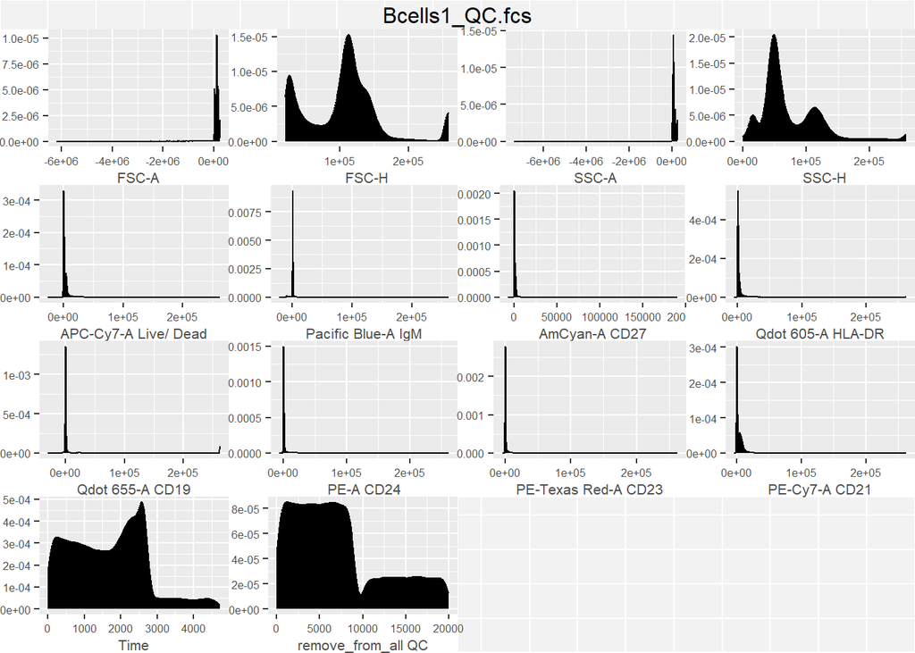

```r
autoplot(fs_qc[[1]])
```

Let’s filter out the poor quality events above 10000.

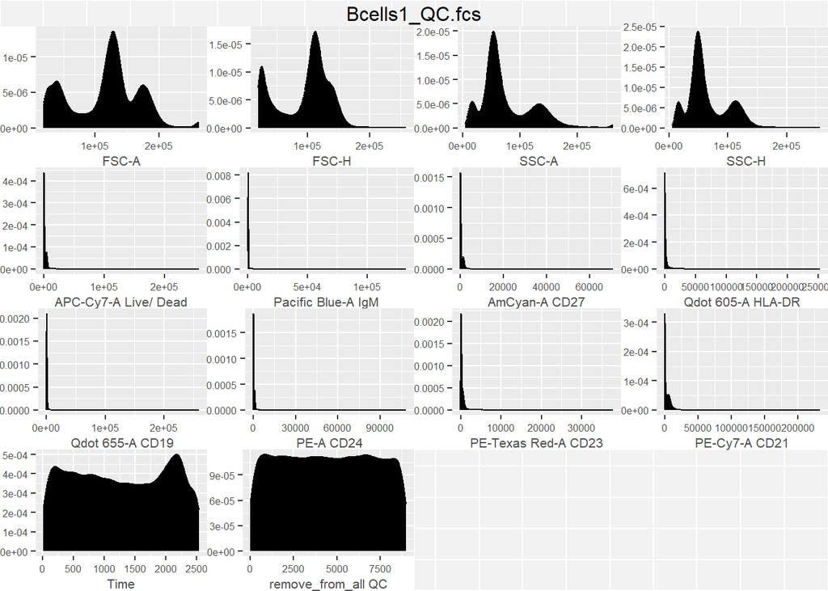

```r
qcGate <- rectangleGate(filterId = "highQuality","remove_from_all" = c(-Inf, 10000))
qc_filt <- flowCore::filter(x = fs_qc, qcGate)
fs_qc_filt <- flowCore::Subset(x = fs_qc, subset = qc_filt)

autoplot(fs_qc_filt[[1]]) # Only events under 10k remain in the remove_from_all channel
```

### Preprocessing

#### Compensation

For situations where the overlap of the fluorochromes occurs, it is important to run compensation. If available, you may find the compensation matrix directly in the file using the keywords.

```r
comp <- keyword(fs_qc_filt[[1]])[["SPILL"]]
comp # The matrix provides the information on how much signal to subtract out of one channel from another
```

```
##      APC-Cy7-A Pacific Blue-A AmCyan-A Qdot 605-A Qdot 655-A     PE-A
## [1,]  0.096519        0.00000 0.000000   0.000000   0.082008 0.000000
## [2,]  0.329188        0.00000 0.000000   0.000000   0.000000 0.000000
## [3,]  1.000000        0.00000 0.000000   0.000000   0.000000 0.000000
## [4,]  0.000000        1.00000 0.147662   0.014766   0.001376 0.000000
## [5,]  0.000000        0.07477 1.000000   0.494414   0.128913 0.000000
## [6,]  0.000000        0.00000 0.000000   0.000000   0.000000 0.000000
## [7,]  0.000000        0.00000 0.000000   0.000000   0.000000 0.000000
## [8,]  0.000000        0.00000 0.000000   1.000000   0.019277 0.013372
##      PE-Texas Red-A PE-Cy7-A
## [1,]        0.00098 0.021455
## [2,]        0.00000 0.044144
## [3,]        0.00000 0.000000
## [4,]        0.00000 0.000000
## [5,]        0.00000 0.000000
## [6,]        0.00000 0.000000
## [7,]        0.00000 0.000000
## [8,]        0.12903 0.000000
```

```r
keyword(fs_qc_filt[[1]])[["APPLY COMPENSATION"]] # Compensation is already performed so we don't need to
```

```
## [1] "TRUE"
```

The `fsApply` function can apply a flow cytometry function to each flow frame within a flow set. Let’s use this function to decompensate the data and we’ll compare the effect with the compensated data.

```r
fs_qc_filt_decomp <- fsApply(fs_qc_filt, FUN = function(ff) decompensate(ff, comp))
```

We can use the ggcyto package to do ggplot2 type visualizations! Here we compare a couple of channels with overlap from the compensation matrix with biological significance.

```r
plot_comp <- ggcyto(fs_qc_filt[[1]], aes("Pacific", "655-A")) + geom_hex(bins = 512) + scale_x_flowjo_biexp() + scale_y_flowjo_biexp() + ggtitle("Compensated")
plot_uncomp <- ggcyto(fs_qc_filt_decomp[[1]], aes("Pacific", "655-A")) + geom_hex(bins = 512) + scale_x_flowjo_biexp() + scale_y_flowjo_biexp() + ggtitle("Uncompensated")
```

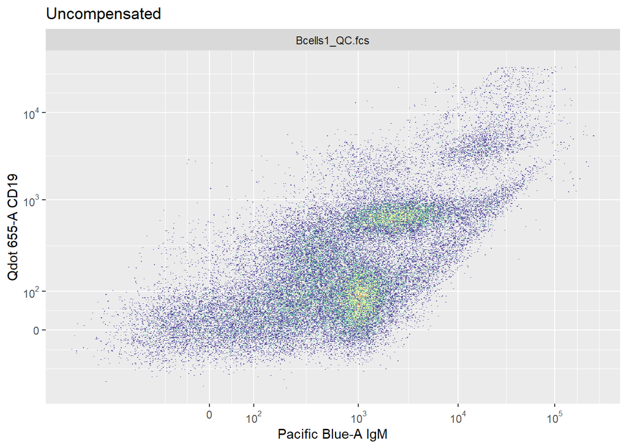

```r
plot_uncomp + ggtitle("Uncompensated")
```

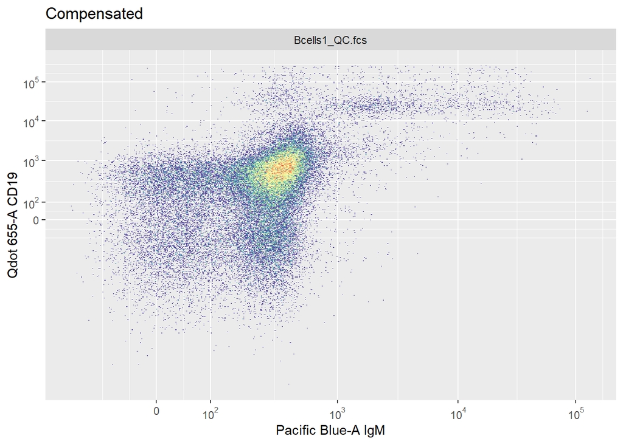

```r
plot_comp + ggtitle("Compensated")
```

#### Additional Preprocessing

Let’s also remove any margin events (not always needed and depends upon experiment). We remove from scatter channels.

```r
bf <- boundaryFilter(x = c("FSC-A", "SSC-A", "FSC-H", names(markers_of_interest)), filterId = "boundaryFilt")
fs_qc_filt_margins <- flowCore::Subset(x = fs_qc_filt, subset = bf)
```

#### Data visualization and Transformation

On the untransformed data, it is hard to see differences across the color channels without transformation. Also note that the remove_from_all QC channel is limited to below 10000.

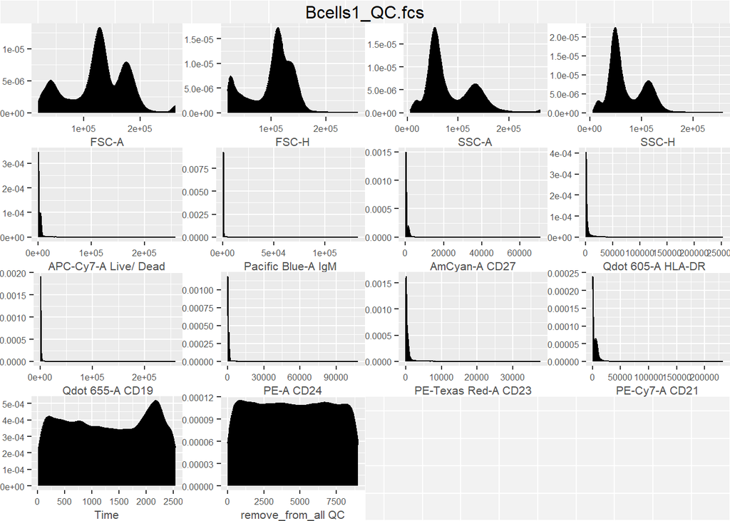

```r
autoplot(fs_qc_filt_margins[[1]])
```

Logicle Transformation is one approach to allowing better visualization of the color channels.

```r
trans <- logicle_trans()
trans <- transformList(from = names(markers_of_interest), logicleTransform())

fs_qc_filt_margins_trans <- transform(fs_qc_filt_margins, trans)
```

Now the plots for the color channels are transformed for visualization

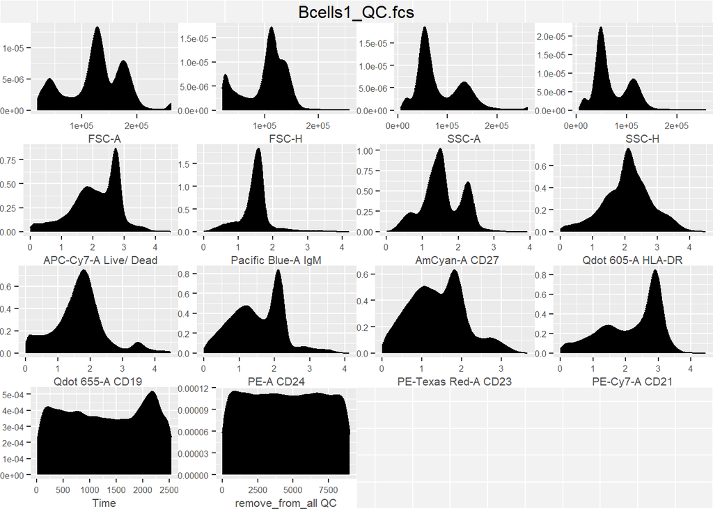

```r
autoplot(fs_qc_filt_margins_trans[[1]])
```

### Gating

Let’s use `openCyto` to perform some common gating steps in a more automated fashion.

```r
gs <- GatingSet(fs_qc_filt_margins_trans)
```

Let’s examine our cells by FSC and SSC.

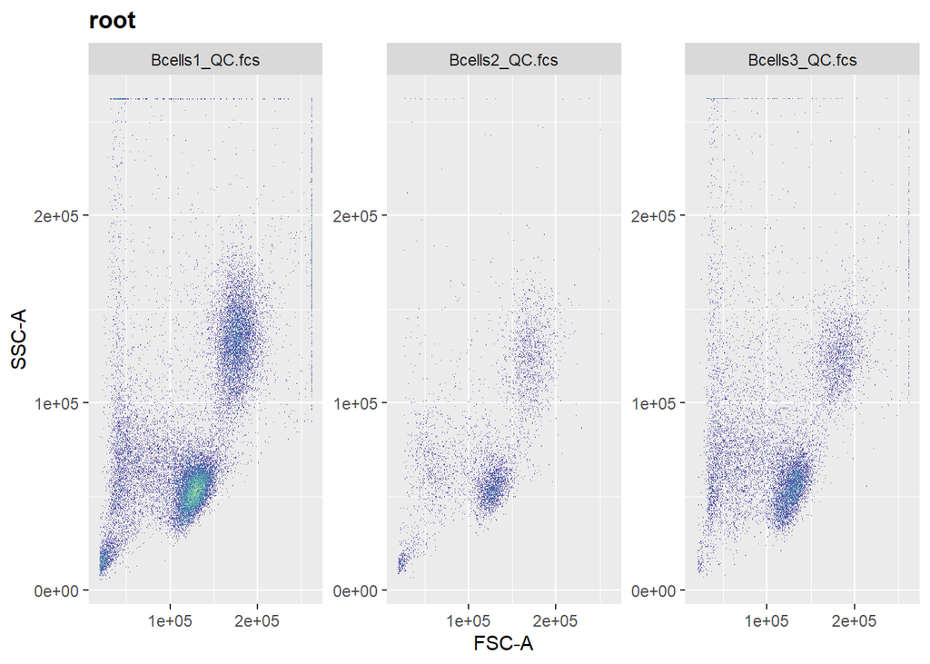

```r
ggcyto(data = gs, aes(`FSC-A`, `SSC-A`), subset = "root") + geom_hex(bins = 512)
```

```r
gs_add_gating_method(gs = gs, alias = "nonDebris", dims = "FSC-A", pop = "+",
                     parent = "root", gating_method = "mindensity", gating_args = "peaks = c(0,1.25e05)")
```

```
## ...
```

```
## done
```

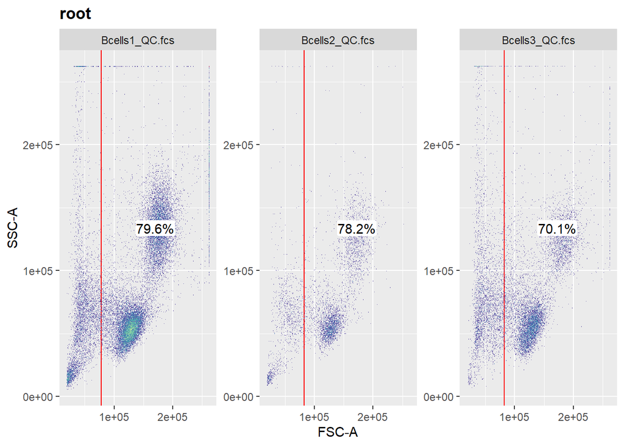

```r
ggcyto(gs, aes("FSC-A", "SSC-A"), subset = "root") + geom_gate("nonDebris") + geom_hex(bins = 512) + geom_stats()
```

Now we add a lymphocytes gate around the events with debris removed.

```r
gs_add_gating_method(gs, alias = "lymphocytes", pop = "+", parent = "nonDebris", dims = "FSC-A,SSC-A",
                     gating_method = "flowClust.2d", gating_args = "K=2, target=c(1e05,5e04),quantile=0.95"
                    )
```

```
## ...
```

```
## done
```

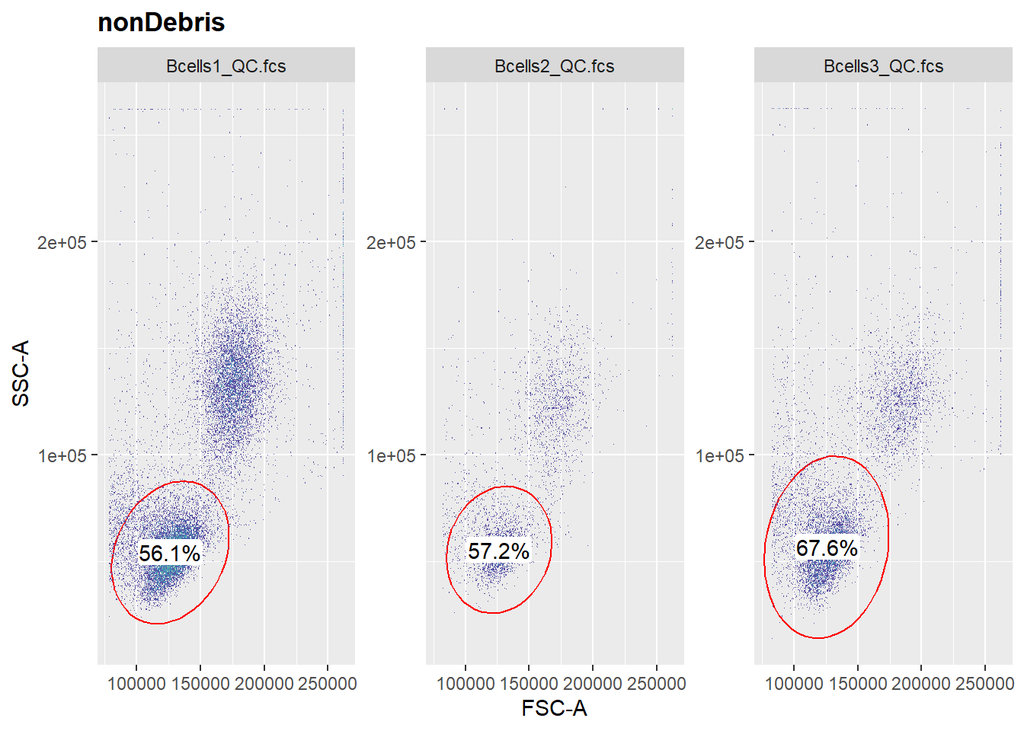

```r
ggcyto(gs, aes("FSC-A", "SSC-A"), subset = "nonDebris") + geom_gate("lymphocytes") + geom_hex(bins = 512) + geom_stats()
```

Let’s add a single gate on the lymphocytes population.

```r
gs_add_gating_method(gs, alias = "singlets", pop = "+", parent = "lymphocytes", dims = "FSC-A,FSC-H",
                     gating_method = "singletGate")
```

```
## ...
```

```
## done
```

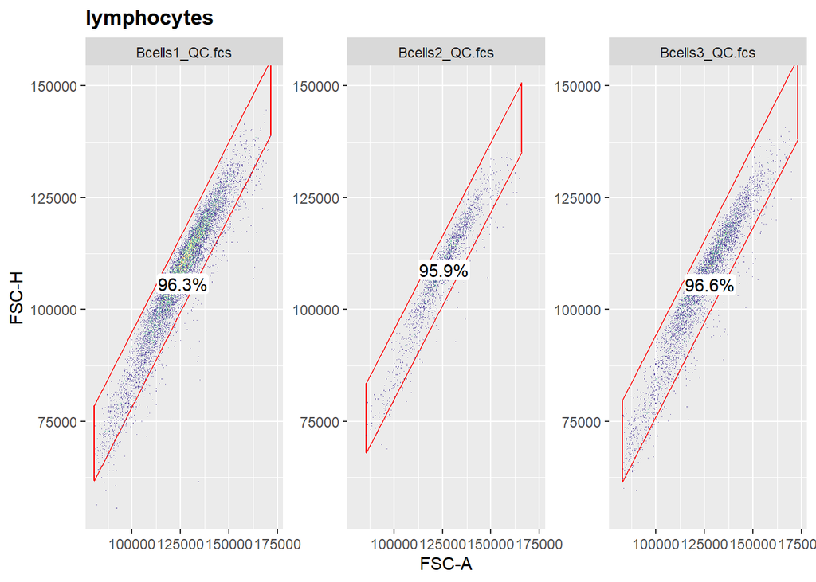

```r
ggcyto(gs, aes("FSC-A", "FSC-H"), subset = "lymphocytes") + geom_gate("singlets") + geom_hex(bins = 512) + geom_stats()
```

Finally, we gate CD19+ events on the singlets.

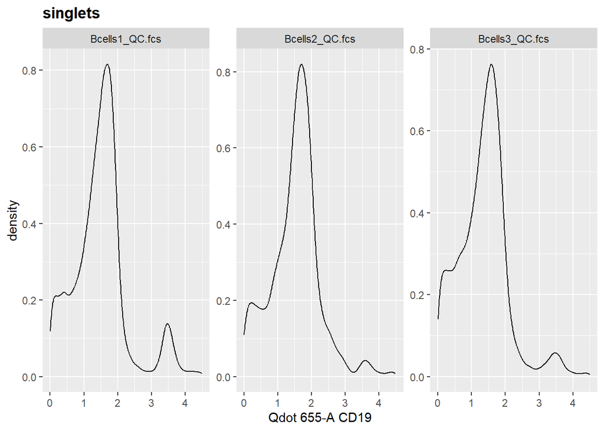

```r
ggcyto(gs, aes(x="CD19"), subset = "singlets") + geom_density()
```

```r
gs_add_gating_method(gs, alias = "bcells", pop = "+", parent = "singlets", dims = "CD19",
                     gating_method = "mindensity")
```

```
## ...
```

```
## done
```

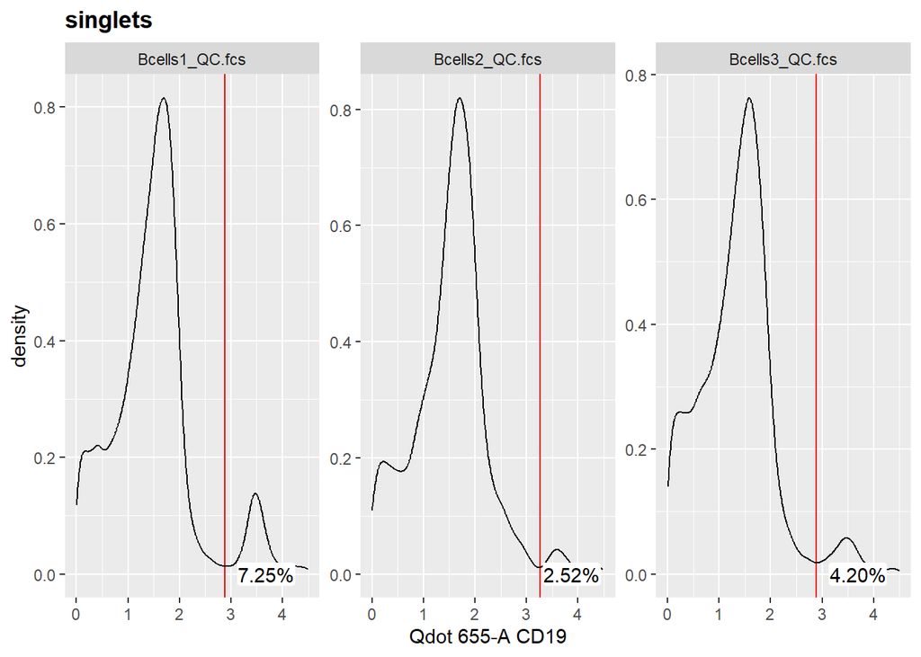

```r
ggcyto(gs, aes("CD19"), subset = "singlets") + geom_gate("bcells") + geom_density() + geom_stats()
```

Now let’s do some statistical analysis on the means and median in each gated population.

```r
gs_stats <- gs_pop_get_count_fast(x = gs, type = "count")
gs_stats <- left_join(gs_stats, gs_pop_get_count_fast(x = gs, statistic = "freq"))
gs_stats <- dplyr::mutate(gs_stats, freq_of_parent = Count/ParentCount)

pop.median <- function(fr){
  chnls <- colnames(fr)
  res <- matrixStats::colMedians(exprs(fr))
  names(res) <- chnls
  res
}

pop.mean <- function(fr){
  chnls <- colnames(fr)
  res <- matrixStats::colMeans2(exprs(fr))
  names(res) <- chnls
  res
}

gs_stats_mean <-  left_join(gs_stats, gs_pop_get_stats(x = gs, type = pop.mean) %>% dplyr::rename("name" = "sample", "Population" = "pop"))
gs_stats_median <-  left_join(gs_stats, gs_pop_get_stats(x = gs, type = pop.median) %>% dplyr::rename("name" = "sample", "Population" = "pop"))
```